# Recalling Words

```r
library(mosaic)
library(car)
library(pander)
library(DT)
library(tidyverse)

Fr2 <- Friendly
Fr2 <- filter(Fr2, condition %in% c("Before", "Meshed"))


#You may need to run: install.packages("DT")
```

```r
# Play the chunk above and this one to get the data into your Console
# Note the eval=FALSE statement in this R-chunk will exclude this code
# from running when you Knit and will only work in the Console.
View(Friendly)
?Friendly
```

## Background

Many teachers and other educators are interested in understanding how to best deliver new content to students. In general, they have two choices of how to do this.

1. The Meshed Approach
   - Deliver new content while simultaneously reviewing previously understood content.
2. The Before Approach
   - Deliver new content after fully reviewing previously understood content.

A study was performed to determine whether the *Meshed* or *Before* approaches to delivering content had any positive benefits on memory recall.

### Show the Experiment Details

Individuals were seated at a computer and shown a list of words. Words appeared on the screen one at a time, for two seconds each, until all words had been shown (40 total). After all words were shown, they were required to perform a few two-digit mathematical additions (like 15 + 25) for 15 seconds to avoid immediate memory recall of the words. They were then asked to write down as many of the 40 words as they could remember. They were given a maximum of 5.3 minutes to recall words.

The process of showing words and recalling words was repeated four times with the same list of words each time (four chances to get it right). The presentation of the first trial was the same for all treatment conditions. However, trials 2, 3, and 4 were slightly different for each treatment condition.

The `SFR` group (the control group) stands for Standard Free Recall. In all four trials the same list of 40 words was presented, in a random order each time.

The `Before` group also used the same 40 words during each trial. However, any words that were correctly recalled in a previous trial were presented first, or *before* the words that were not recalled in the last trial. After all the correct words were presented in random order, the non-recalled words were presented in a random order.

The `Meshed` group also used the same 40 words during each trial. However, words that were correctly recalled in a previous trial were alternated with a missed word during the next presentation order.

The data records the number of correctly recalled words (out of the 40 possible) from the fourth trial. Results were obtained for 30 students, 10 in each of the three treatment groups: `SFR`, `Before`, and `Meshed`.

### Show the Data

The results from the study can be found in the `Friendly` data set in R after loading `library(car)`.

Click the “Code” button to see the data.

```r
datatable(Friendly, options=list(lengthMenu = c(3,10,30)))
```

|  | condition | correct |
| --- | --- | --- |
| 1 | SFR | 39 |
| 2 | SFR | 25 |
| 3 | SFR | 37 |
| 4 | SFR | 25 |
| 5 | SFR | 29 |
| 6 | SFR | 39 |
| 7 | SFR | 21 |
| 8 | SFR | 39 |
| 9 | SFR | 24 |
| 10 | SFR | 25 |

[output cut: 20 more lines]

## Analysis

### Research Question

Based on the background information above, the important question this analysis seeks to answer is whether or not the Meshed or Before methods or groups demonstrate any positive benefits on memory recall tests. This will be examined using the Wilcoxon Rank Sum (Mann-Whitney) test, to determine if there is a difference or not in the median values for each group, which provides an opportunity to examine if one group fares better than another in the memory recall tests. This can be represented symbolically by the following hypothesis statements:

$$H_0: \text{difference in medians} = 0$$

$$H_a: \text{difference in medians} \neq 0$$

The level of significance for this test will be set to:
$$\alpha = 0.05$$

### Graphic

Based on appearance alone in the boxplot below, it would seem that the **Before** condition is more effective than the **Meshed** condition. However, this will be examined further and either confirmed or denied by using a Wilcoxon test to compare the differences in median scores between groups. The thick dark line inside of each boxplot in this case represents the median, with the height of each boxplot demonstrating the spread of the data collected. The empty circles are outliers or extreme values in the data.

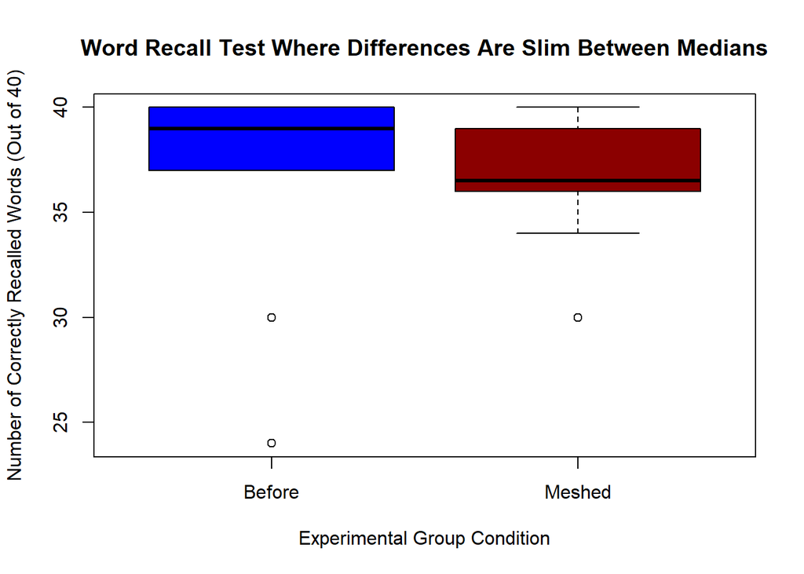

```r
boxplot(correct ~ condition, data=droplevels(Fr2), xlab="Experimental Group Condition", ylab="Number of Correctly Recalled Words (Out of 40)", main="Word Recall Test Where Differences Are Slim Between Medians", col=c("blue", "darkred"))
```

### Numerical Summary

A summary of the values demonstrated in the plot above are shown in the table below. The mean scores of the two groups are exactly the same, while the medians differ slightly, adding weight to the theory that the **Before** condition may yield slightly better benefits than the **Meshed** condition.

```r
 Fr2 %>%
     group_by(condition) %>%
     summarise(min = min(correct), median = median (correct), mean = mean(correct), max = max(correct), sd = sd(correct), `Number of Participants` = n()) %>%
     pander(caption="Summary of Word Recall Test")
```

Summary of Word Recall Test

| condition | min | median | mean | max | sd | Number of Participants |
| --- | --- | --- | --- | --- | --- | --- |
| Before | 24 | 39 | 36.6 | 40 | 5.337 | 10 |
| Meshed | 30 | 36.5 | 36.6 | 40 | 3.026 | 10 |

However, in order to determine if the conclusion that the **Before** group demonstrates positive benefits in memory recall when compared to the **Meshed** group is valid to use as an inference, the Wilcoxon Rank Sum (Mann-Whitney) Test will be used. Note that there are ties present in the Friendly data, so an exact p-value cannot be computed. Instead, an approximation of this value will be used. Due to a small sample size, a continuity correction will also be used.

### Wilcoxon Rank Sum (Mann-Whitney) Test

```r
pander(wilcox.test(correct ~ condition, data=Fr2, mu = 0, alternative="two.sided", conf.level = 0.95))
```

Wilcoxon rank sum test with continuity correction: `correct` by `condition` —-

| Test statistic | P value | Alternative hypothesis |
| --- | --- | --- |
| 62 | 0.378 | two.sided |

### Interpretation

While the results of the test are valid, the p-value of 0.378 demonstrates insufficient evidence to reject the null hypothesis, and so we must fail to reject the null hypothesis. There is not a statistically significant difference between the median values, and thus it cannot be demonstrated that one group provides a positive benefit to memory recall over the other group. This is most notable when examining how close the median scores are. The **Before** group had a median score of **39** words recalled, and the **Meshed** group had a median score of **36.5** words recalled. There is very little meaningful difference between these two scores when it comes to a test of memory. Ultimately, it appears that it is up to the teacher’s discretion what method to use in helping students to retain important information, as either method provides relatively the same amount of benefits in improving memory recall ability.